# Open Data Science 2018

Suvi Virtanen

15 marraskuuta 2018

```r
library(dplyr)
library(tidyr)
library(ggplot2)
library(boot)
```

**Data**

```r
alc <- read.csv("alc.csv", header = T)

str(alc)
```

```
## 'data.frame':    382 obs. of  36 variables:
##  $ X         : int  1 2 3 4 5 6 7 8 9 10 ...
##  $ school    : Factor w/ 2 levels "GP","MS": 1 1 1 1 1 1 1 1 1 1 ...
##  $ sex       : Factor w/ 2 levels "F","M": 1 1 1 1 1 2 2 1 2 2 ...
##  $ age       : int  18 17 15 15 16 16 16 17 15 15 ...
##  $ address   : Factor w/ 2 levels "R","U": 2 2 2 2 2 2 2 2 2 2 ...
##  $ famsize   : Factor w/ 2 levels "GT3","LE3": 1 1 2 1 1 2 2 1 2 1 ...
##  $ Pstatus   : Factor w/ 2 levels "A","T": 1 2 2 2 2 2 2 1 1 2 ...
##  $ Medu      : int  4 1 1 4 3 4 2 4 3 3 ...
##  $ Fedu      : int  4 1 1 2 3 3 2 4 2 4 ...
##  $ Mjob      : Factor w/ 5 levels "at_home","health",..: 1 1 1 2 3 4 3 3 4 3 ...
##  $ Fjob      : Factor w/ 5 levels "at_home","health",..: 5 3 3 4 3 3 3 5 3 3 ...
##  $ reason    : Factor w/ 4 levels "course","home",..: 1 1 3 2 2 4 2 2 2 2 ...
##  $ nursery   : Factor w/ 2 levels "no","yes": 2 1 2 2 2 2 2 2 2 2 ...
##  $ internet  : Factor w/ 2 levels "no","yes": 1 2 2 2 1 2 2 1 2 2 ...
```

[output cut: 22 more lines]

This data approach student achievement in secondary education of two Portuguese schools. The data attributes include student grades, demographic, social and school related features and it was collected by using school reports and questionnaires. The dependent variable in the present report was risky alcohol consumption. First, general level of alcohol consumption was defined as the average of weekday and weekend alcohol consumption (both measured on scale from 1 - very low to 5 - very high). Individual was defined as high-level alcohol user if their averge alcohol consumption was greater than 2.  
The main explanatory variables are sex (male, female), quality of family relationships (numeric: from 1 - very bad to 5 - excellent), mother’s education (numeric: 0 - none, 1 - primary education - 4th grade, 2 - 5th to 9th grade, 3 - secondary education or 4 - higher education), going out with friends (numeric: from 1 - very low to 5 - very high).

**The hypotheses of the present report are as follows:**

1. Male sex is associatied with higher risk of high alcohol consumption
2. Better familiy relationships are protective against high alcohol consumption
3. Mother’s low education predicts higher risk of high alcohol consumption
4. Going out with friends frequently predicts higher risk of high alcohol consumption

Prepararing variables

```r
keep_columns <- c("sex","Medu","famrel", "goout", "high_use")

data <- select(alc, one_of(keep_columns))

str(data)
```

```
## 'data.frame':    382 obs. of  5 variables:
##  $ sex     : Factor w/ 2 levels "F","M": 1 1 1 1 1 2 2 1 2 2 ...
##  $ Medu    : int  4 1 1 4 3 4 2 4 3 3 ...
##  $ famrel  : int  4 5 4 3 4 5 4 4 4 5 ...
##  $ goout   : int  4 3 2 2 2 2 4 4 2 1 ...
##  $ high_use: logi  FALSE FALSE TRUE FALSE FALSE FALSE ...
```

**Variable frequencies**

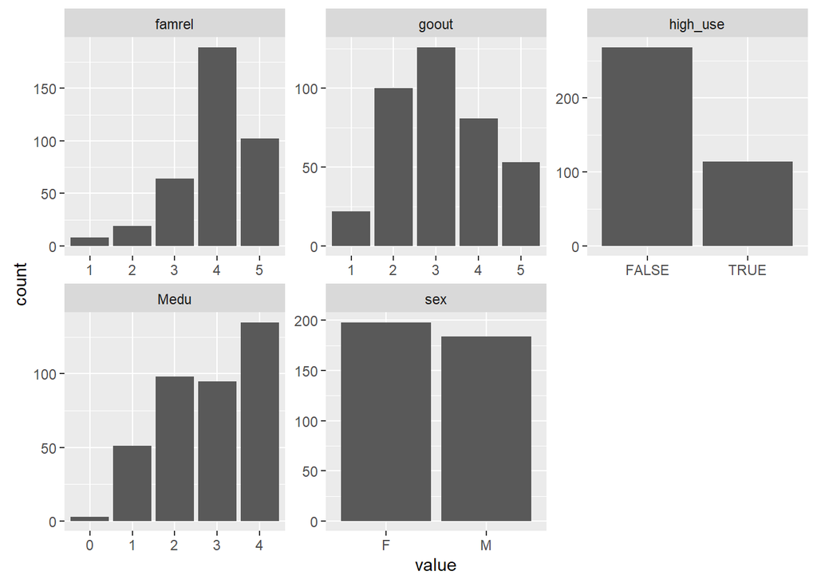

```r
gather(data) %>% ggplot(aes(value)) + facet_wrap("key", scales = "free") + geom_bar()
```

**Associations between dependent and independent variables**  
Family relationships

```r
data %>% group_by(sex, high_use) %>% summarise(count = n(), mean_grade=mean(famrel))
```

```
## Source: local data frame [4 x 4]
## Groups: sex [?]
##
##      sex high_use count mean_grade
##   (fctr)    (lgl) (int)      (dbl)
## 1      F    FALSE   156   3.910256
## 2      F     TRUE    42   3.761905
## 3      M    FALSE   112   4.133929
## 4      M     TRUE    72   3.791667
```

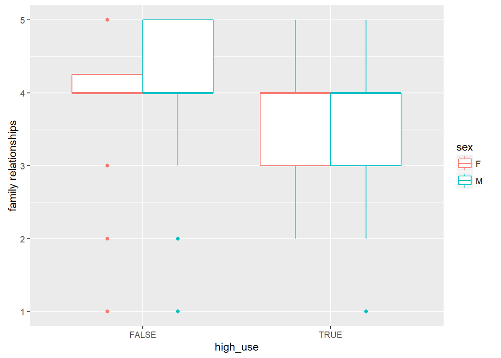

```r
g1 <- ggplot(data, aes(x = high_use, y = famrel, col=sex))


g1 + geom_boxplot() + ylab("family relationships")
```

Above, the results of group mean comparisons and the box plot figure show that the means in family relationship quality were very close to one another in high use and non-high use groups. However, the variance was much larger in the high use group, indicating that in there was more variability in this group in the family relationship quality.

Going out with friends

```r
data %>% group_by(sex, high_use) %>% summarise(count = n(), mean_grade=mean(goout))
```

```
## Source: local data frame [4 x 4]
## Groups: sex [?]
##
##      sex high_use count mean_grade
##   (fctr)    (lgl) (int)      (dbl)
## 1      F    FALSE   156   2.955128
## 2      F     TRUE    42   3.357143
## 3      M    FALSE   112   2.714286
## 4      M     TRUE    72   3.930556
```

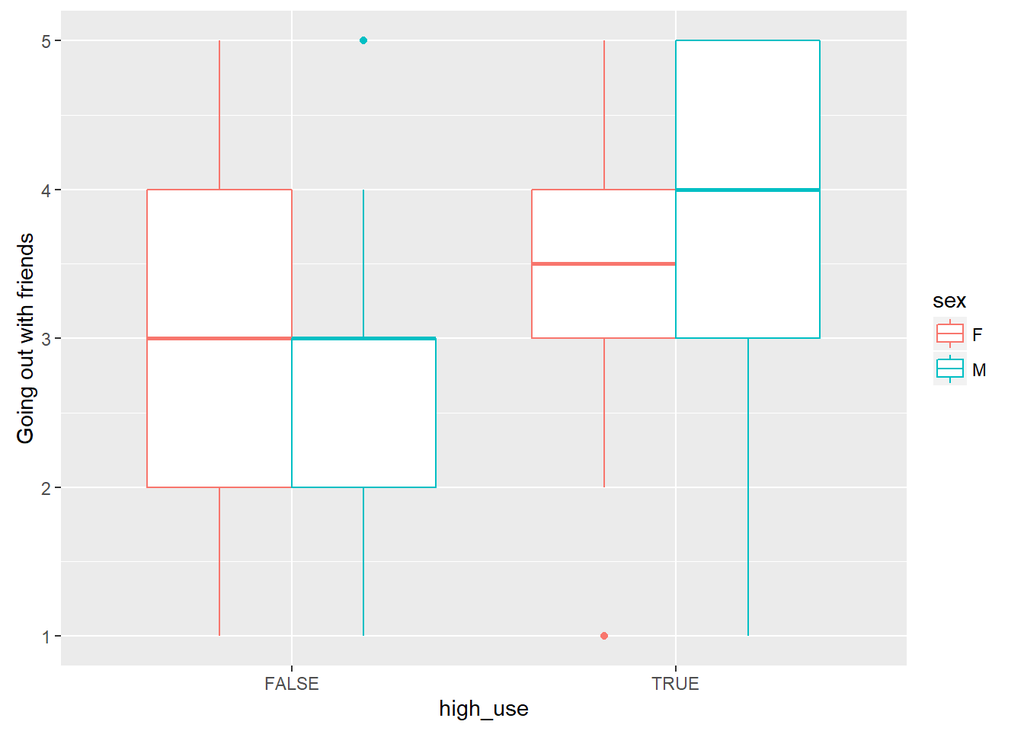

```r
g1 <- ggplot(data, aes(x = high_use, y = goout, col=sex))


g1 + geom_boxplot() + ylab("Going out with friends")
```

The group mean comparisons and the box plot figure show that there appears to be mean differences in the frequency of going out with friends. The group that uses more alcohol goes out with friends more frequently.

Mother’s education

```r
data %>% group_by(sex, high_use) %>% summarise(count = n(), mean_grade=mean(Medu))
```

```
## Source: local data frame [4 x 4]
## Groups: sex [?]
##
##      sex high_use count mean_grade
##   (fctr)    (lgl) (int)      (dbl)
## 1      F    FALSE   156   2.673077
## 2      F     TRUE    42   2.785714
## 3      M    FALSE   112   2.973214
## 4      M     TRUE    72   2.847222
```

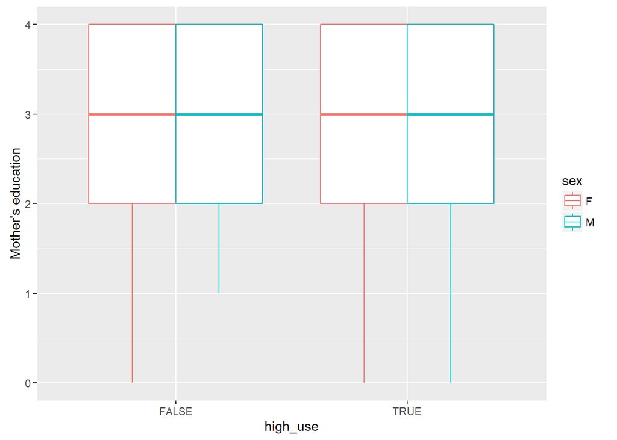

```r
g1 <- ggplot(data, aes(x = high_use, y = Medu, col=sex))


g1 + geom_boxplot() + ylab("Mother's education")
```

There seems to be no clear differences between high risk and non-high risk alcohol users regarding mother’s education.

**Logistic regression**

```r
m <- glm(high_use ~ sex + famrel + goout + Medu, data = alc, family = "binomial")
summary(m)
```

```
##
## Call:
## glm(formula = high_use ~ sex + famrel + goout + Medu, family = "binomial",
##     data = alc)
##
## Deviance Residuals:
##     Min       1Q   Median       3Q      Max
## -1.5528  -0.7881  -0.5278   0.8438   2.5588
##
## Coefficients:
##             Estimate Std. Error z value Pr(>|z|)
## (Intercept)  -2.1725     0.7062  -3.076 0.002095 **
## sexM          0.9476     0.2526   3.751 0.000176 ***
## famrel       -0.4148     0.1388  -2.989 0.002803 **
## goout         0.8013     0.1217   6.584 4.58e-11 ***
## Medu         -0.0682     0.1139  -0.599 0.549340
## ---
## Signif. codes:  0 '***' 0.001 '**' 0.01 '*' 0.05 '.' 0.1 ' ' 1
##
## (Dispersion parameter for binomial family taken to be 1)
##
##     Null deviance: 465.68  on 381  degrees of freedom
## Residual deviance: 393.44  on 377  degrees of freedom
## AIC: 403.44
##
## Number of Fisher Scoring iterations: 4
```

Computing Odds Ratios

```r
OR <- coef(m) %>% exp
CI <- confint(m) %>% exp
cbind(OR, CI)
```

```
##                    OR     2.5 %    97.5 %
## (Intercept) 0.1138880 0.0273881 0.4400122
## sexM        2.5794294 1.5810282 4.2643295
## famrel      0.6604684 0.5014022 0.8655158
## goout       2.2285055 1.7673133 2.8509142
## Medu        0.9340696 0.7470098 1.1687385
```

The logistic regression model shows that all variables but mother’s education had statistically significant relationsips with alcohol consumption (p-value less than 0.05).

Boys, compared to girls, had 2.6 times the odds of being a high risk alcohol user. This result provides support for the first hypothesis of gender differences in high risk alcohol use.

Increase in going out with friends increased the odds of high risk alcohol use. This is also in line with the original hypothesis.

Further, as relationship quality with family decreased, the odds of high risk increased. The result supports the hypothesis that worse family relationships would increase the risk of alcohol consumption.

**Model performance**

Family relationship

```r
probabilities <- predict(m, type = "response")
data <- mutate(data, probability = probabilities)
data <- mutate(data, prediction = probability > 0.5)
select(data, famrel, goout, sex, high_use, probability, prediction) %>% tail(10)
```

```
##     famrel goout sex high_use probability prediction
## 373      4     2   M    FALSE  0.20591330      FALSE
## 374      5     3   M     TRUE  0.23724833      FALSE
## 375      5     3   F    FALSE  0.12142711      FALSE
## 376      4     3   F    FALSE  0.15438857      FALSE
## 377      5     2   F    FALSE  0.05839718      FALSE
## 378      4     4   F    FALSE  0.30342270      FALSE
## 379      2     2   F    FALSE  0.18729340      FALSE
## 380      1     1   F    FALSE  0.13537830      FALSE
## 381      2     5   M     TRUE  0.85163207       TRUE
## 382      4     1   M     TRUE  0.09216541      FALSE
```

```r
table(high_use = data$high_use, prediction = data$prediction)
```

```
##         prediction
## high_use FALSE TRUE
##    FALSE   247   21
##    TRUE     65   49
```

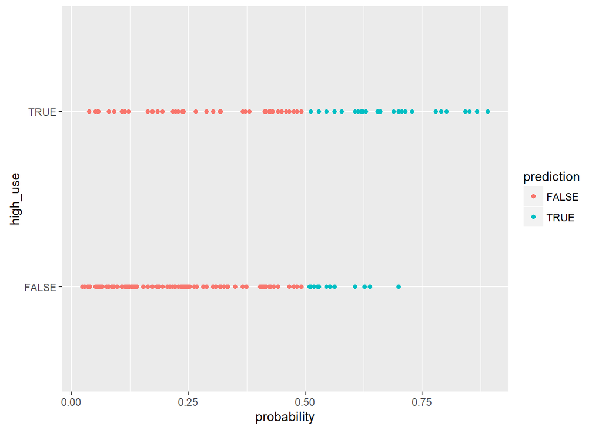

```r
g <- ggplot(data, aes(x = probability, y = high_use, col = prediction))
g + geom_point()
```

```r
table(high_use = data$high_use, prediction = data$prediction) %>% prop.table() %>% addmargins()
```

```
##         prediction
## high_use      FALSE       TRUE        Sum
##    FALSE 0.64659686 0.05497382 0.70157068
##    TRUE  0.17015707 0.12827225 0.29842932
##    Sum   0.81675393 0.18324607 1.00000000
```

Average number of wrong predictions in the (training) data & 10-fold cross-validation

```r
loss_func <- function(class, prob) {
  n_wrong <- abs(class - prob) > 0.5
  mean(n_wrong)
}

loss_func(class = data$high_use, prob = data$probability)
```

```
## [1] 0.2251309
```

```r
cv <- cv.glm(data = data, cost = loss_func, glmfit = m, K = 10)

cv$delta[1]
```

```
## [1] 0.2356021
```

The error of 0.24 was found in the 10-fold cross-validation, which is slightly better than the 0.26 error in the DataCamp exercises.